# 245B Machine Learning Workshop

Jake Oxendine adapted from Tony Capra and Cam Nugent

2025-03-03

# Intro to Machine Learning Workshop

**Goal:** In this workshop, you will train machine learning models to identify regions of the genome that change their chromatin accessibility between ovarian cancer cells that are sensitive vs. resistant to platinum-based chemotherapeutics like cisplatin. You will use features of these genomic regions like their chromatin accessibility and presence of platinum adducts in other relevant cell types.

**Background:** The data for this project come from the recent paper: https://clinicalepigeneticsjournal.biomedcentral.com/articles/10.1186/s13148-021-01105-6 Please see it and the lecture slides for background on this project. The raw data generated in this paper are available from GEO: https://www.ncbi.nlm.nih.gov/geo/query/acc.cgi?acc=GSE149147

**Materials:** You have been provided a tab-delimited text file (gallon21_peo1_v_peo4_access_data.tab) that contains the coordinates of genomic regions (in reference to the hg19/GRCh37 genome build) that either change (positives) or do not change (negatives) their chromatin accessibility between cisplatin sensitive ovarian cancer cells (PEO1) and cisplatin-resistant ovarian cancer cells (PEO4). This file also contains many attributes of these genomic regions that you will use as features in the machine learning models you train.

## Set Up

```r
#install.packages("caret")
```

## Reading in the data

Read in the data and examine it to see what is available.

```r
setwd("~/Documents/'25 Winter/PSPG 245B.2/R code/245B.2 R/Machine_Learning_Workshop")
data <- read.delim("gallon21_peo1_v_peo4_access_data.tab", header = TRUE, stringsAsFactors = FALSE)

head(data)
```

```
##   X.chrom   start    stop a2780_access cp70_access PEA1_access PEA2_access
## 1    chr1  858600  859600     2.008030     3.03009    2.320570     2.36075
## 2    chr1 1281600 1282600     1.058510     2.00176    0.989123     1.46803
## 3    chr1 1310400 1311400     4.543910     5.18349    3.310290     3.43803
## 4    chr1 1368900 1369900     1.418300     3.13045    0.766330     1.91325
## 5    chr1 1376100 1377100     1.580540     2.26624    0.815680     1.28499
## 6    chr1 1713600 1714600     0.871881     1.37013    0.604083     3.83423
##   PEO1_access  PEO1_pt  PEO4_pt promoter_overlap diff_access_PEO1_v_PE04
## 1    3.289860  8.33333 13.33330              YES                   FALSE
## 2    1.013550 11.00000  4.33333               NO                   FALSE
## 3   15.591900 11.66670 11.00000              YES                   FALSE
## 4    7.702910  6.33333 11.33330              YES                   FALSE
## 5    0.332391 12.66670  7.66667               NO                   FALSE
## 6    3.947280 23.33330 20.00000               NO                   FALSE
```

The columns are: *chrom*: the chromosome of the region (hg19)

*start*: the starting chromosome coordinate (hg19) of the region

*stop:* the ending chromosome coordinate (hg19) of the region

*a2780_access*: the average chromatin accessibility of this region in a2780 cells (see manuscript for description of cell types)

*cp70_access*: the average chromatin accessibility of this region in cp70 cells

*PEA1_access*: the average chromatin accessibility of this region in PEA1 cells

*PEA2_access*: the average chromatin accessibility of this region in PEA2 cells

*PEO1_access*: the average chromatin accessibility of this region in PEO1 cells

*PEO1_pt*: the average pt-Exo-seq signal for PEO1 cells

*PEO4_pt:* the average pt-Exo-seq signal for PEO4 cells *promoter_overlap*: whether the region overlaps a gene’s promoter region

And finally, we have the label we want to predict: *diff_access_PEO1_v_PEO4*: whether the region was differentially accessible between PEO1 and PEO4 cells on average.

## Step 1: Exploring the data

Answer the following questions either with words or with outputs generated by R. Please include the code that you used to generate them:

1. How many input features are there?

11 Total Features

```r
num_features <- ncol(data) - 1 #do not include what is being predicted
num_features
```

```
## [1] 11
```

2. How many genomic regions are labeled as positives? And as negatives?

Positives (TRUE): 664 Negatives (False): 1500

```r
table(data$diff_access_PEO1_v_PE04)
```

```
##
## FALSE  TRUE
##  1500   664
```

3. Plot histograms of all the features. Are they on the same scale? (*Hint check out the melt function with ggplot)*

All histograms have been completed (code below encodes for them). They are not all on the same scale becuase there are large differneces in the scale of the x-axis and y-axes for the plots.

```r
melted_data <- melt(data[,1:(ncol(data))])
```

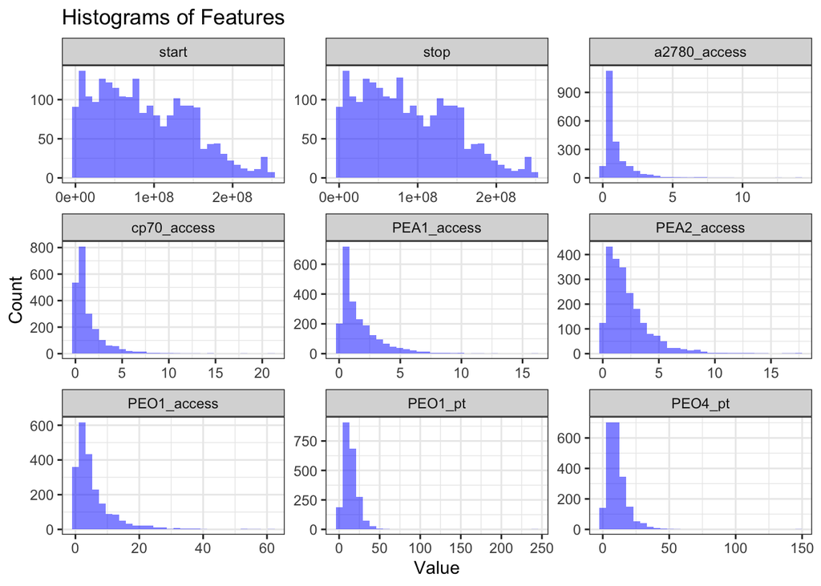

```r
ggplot(melted_data, aes (x = value))+
  geom_histogram(bins = 30, fill = "blue", alpha = 0.5)+
  facet_wrap(~variable, scales = "free")+
  theme_bw()+
  labs(title = "Histograms of Features", x = "Value", y="Count")
```

4. Plot scatter plots of all pairs of the features.

Plots have all been created via the following code:

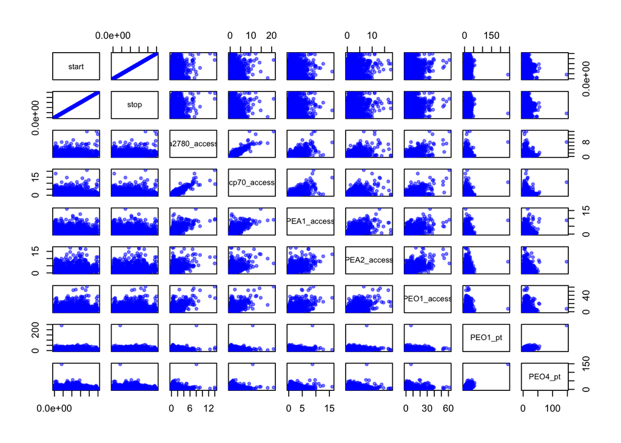

```r
numeric_data <- data[,sapply(data, is.numeric)]
pairs(numeric_data, pch = 20, col = rgb(0, 0, 1, 0.5))
```

5. Compute Spearman correlations between all pairs of features. Are any features strongly correlated?

There are strongly correlated features. There are strong positive correlations between a2780_access and cp70_access as well as a strong correlation between a2780 access and PEA1_access. There also exists a positive correlation between cp70_access and PEA1_access. Other features hae some weaker correlation that is shown in the plot below:

```r
cor_matrix <- cor(numeric_data, method = "spearman")
print(cor_matrix)
```

```
##                     start         stop a2780_access  cp70_access  PEA1_access
## start         1.000000000  1.000000000 -0.008832447 -0.063589457  0.020266832
## stop          1.000000000  1.000000000 -0.008832447 -0.063589457  0.020266832
## a2780_access -0.008832447 -0.008832447  1.000000000  0.911455596  0.663184921
## cp70_access  -0.063589457 -0.063589457  0.911455596  1.000000000  0.667572037
## PEA1_access   0.020266832  0.020266832  0.663184921  0.667572037  1.000000000
## PEA2_access   0.123478337  0.123478337  0.350431403  0.325784209  0.538322708
## PEO1_access   0.126759381  0.126759381  0.246589134  0.225013583  0.346522263
## PEO1_pt       0.119549751  0.119549751 -0.035411277 -0.034512298 -0.015728680
## PEO4_pt       0.055784418  0.055784418 -0.012929218 -0.007199485  0.001078459
##              PEA2_access PEO1_access     PEO1_pt      PEO4_pt
## start         0.12347834  0.12675938  0.11954975  0.055784418
## stop          0.12347834  0.12675938  0.11954975  0.055784418
## a2780_access  0.35043140  0.24658913 -0.03541128 -0.012929218
## cp70_access   0.32578421  0.22501358 -0.03451230 -0.007199485
## PEA1_access   0.53832271  0.34652226 -0.01572868  0.001078459
## PEA2_access   1.00000000  0.43440665  0.02818635 -0.042902226
## PEO1_access   0.43440665  1.00000000  0.11918132 -0.023383409
## PEO1_pt       0.02818635  0.11918132  1.00000000  0.393972342
## PEO4_pt      -0.04290223 -0.02338341  0.39397234  1.000000000
```

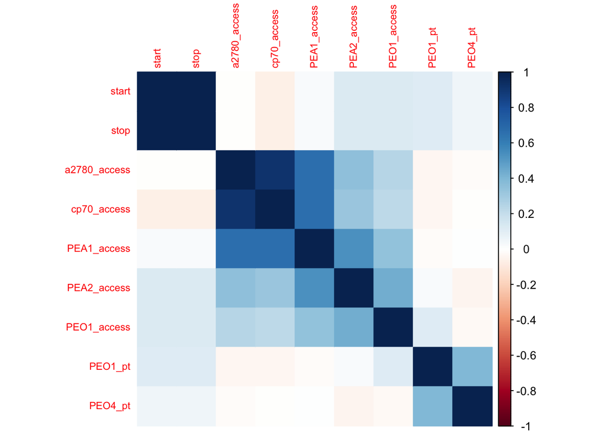

```r
library(corrplot)
corrplot(cor_matrix, method = "color", tl.cex = 0.7)
```

6. Do any individual features substantially differ between the positives and negatives?

Between the positives and negatives, a2780 access, cp70 access, PEA1 access, and PEO1 access substantially (i.e. signficantly differ when seen in a violin plot) differ.

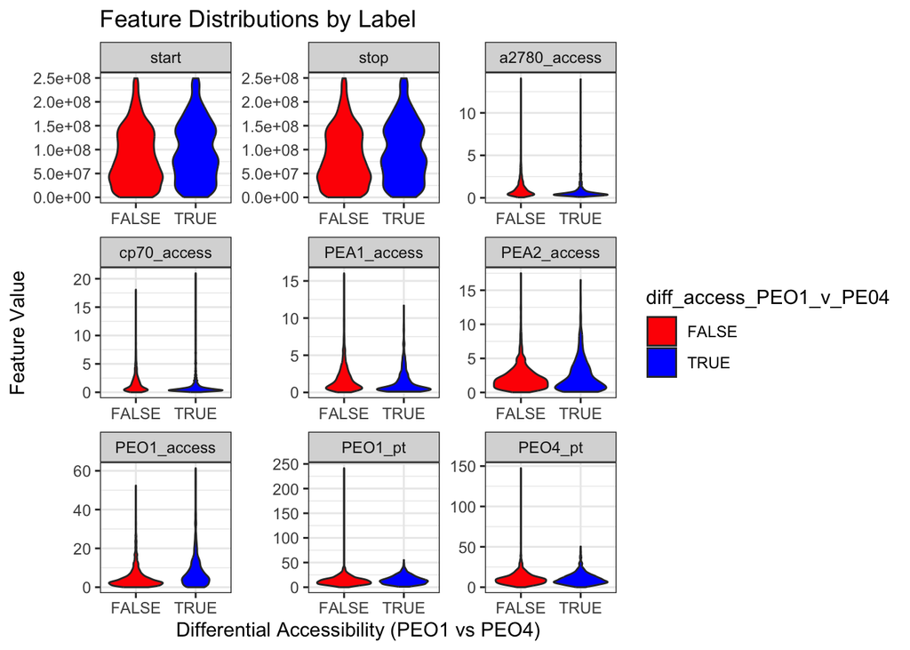

```r
ggplot(melted_data, aes(x = diff_access_PEO1_v_PE04, y = value, fill = diff_access_PEO1_v_PE04)) +
  geom_violin(outlier.shape = NA) +  # Avoid overlapping outliers
  facet_wrap(~variable, scales = "free") +
  theme_bw() +
  labs(title = "Feature Distributions by Label", x = "Differential Accessibility (PEO1 vs PEO4)", y = "Feature Value") +
  scale_fill_manual(values = c("red", "blue"))
```

```r
wilcoxon_results <- melted_data %>%
  select(diff_access_PEO1_v_PE04, variable, value) %>%  # Remove non-numeric columns
  group_by(variable) %>%
  summarise(
    p_value = wilcox.test(value ~ diff_access_PEO1_v_PE04, data = cur_data(), exact = FALSE)$p.value
  ) %>%
  arrange(p_value)
# Print results
print(wilcoxon_results)
```

```
## # A tibble: 9 × 2
##   variable      p_value
##   <fct>           <dbl>
## 1 cp70_access  5.23e-25
## 2 a2780_access 1.92e-23
## 3 PEO1_access  3.85e-22
## 4 PEA1_access  2.48e-15
## 5 start        4.84e- 6
## 6 stop         4.84e- 6
## 7 PEO1_pt      1.37e- 5
## 8 PEA2_access  3.40e- 1
## 9 PEO4_pt      4.72e- 1
```

7. Are there any missing values in the features or labels? There is no missing data or labels as evidenced by the code below:

```r
sum(is.na(data))
```

```
## [1] 0
```

```r
colSums(is.na(data))
```

```
##                 X.chrom                   start                    stop
##                       0                       0                       0
##            a2780_access             cp70_access             PEA1_access
##                       0                       0                       0
##             PEA2_access             PEO1_access                 PEO1_pt
##                       0                       0                       0
##                 PEO4_pt        promoter_overlap diff_access_PEO1_v_PE04
##                       0                       0                       0
```

## Step 2: Cleaning the data

You may not need to do all of these but you should consider

*Fixing missing values*

*Creating or converting categorical values*

*Scaling numerical values*

*Creating any new values that you think might be useful*

```r
#no missing data, no columns being created for now, no exclusion for now
#convert booleans to 0 and 1 (0 is false, 1 is true)
data <- data %>%
  mutate(across(where(is.logical), as.numeric))

#promoeter overlap to 0 and 1 (0 is no, 1 is yes)
data <- data %>%
  mutate(across(where(is.character), ~ ifelse(. == "YES", 1, ifelse(. == "NO", 0, .))))
```

## Step 3: Creating a training data set

Set aside 20% of the positives and negatives as a test set for use in Step 3. The remaining 80% will be your training/validation set for us in this step.

```r
set.seed(14) # Set a random seed so that same sample can be reproduced in future runs


sample <- sample.int(n = nrow(data), size = floor(.8*nrow(data)), replace = F)
train <- data[sample, ]  # Select the rows corresponding to the sample
test  <- data[-sample, ] # Select all rows except the ones in the sample

#scaling the train and test dataset separately
train <- train %>%
  mutate(across(c(a2780_access, cp70_access, PEA1_access, PEA2_access, PEO1_access, PEO1_pt, PEO4_pt), ~scale(.)[, 1]))

test <- test %>%
  mutate(across(c(a2780_access, cp70_access, PEA1_access, PEA2_access, PEO1_access, PEO1_pt, PEO4_pt), ~scale(.)[, 1]))
```

1. Did you select regions for the test set randomly or by another criteria? Why?

I randomly selected regions for the test set to ensure an unbiased and representative distribution of the data. Random selection helps prevent any unintended patterns or biases that might arise if the test set were chosen based on specific criteria. This approach ensures that the model is evaluated on a diverse and unseen subset of data, making the results more generalizable to new data. Additionally, random sampling helps maintain the class distribution (ratio of positives to negatives) in both training and test sets, preventing imbalanced learning.

*Consider the features you’d like to use to train the algorithms.*

2. Did you include all features in the models you trained? Why or why not?

I included all the features in the dataset but I will not be using the start and stop for now. Additionally, I will not be including the X.chrom for now.

3. Did you transform the input features? If so, how and why? Yes, I transformed the input features via scaling by z-scores after separating by test and train. This is done to ensure data normalizationa cross categories/variables.
4. Are there any categorical features? If so, how should you encode them numerically? There are categorial features (promoter overlap). These are yes and no, and these have been encoded as 1 and 0 respectively.

*You will want to split the x and y from your trainset*

```r
train_y <- train$diff_access_PEO1_v_PE04
train_x <- train %>%
  select(-diff_access_PEO1_v_PE04, -start, -stop, -X.chrom)

test_y <- test$diff_access_PEO1_v_PE04
test_x <- test %>%
  select(-diff_access_PEO1_v_PE04, -start, -stop, -X.chrom)


rf_train <- train %>%
  select(-start, -stop, -X.chrom)
rf_test <- test %>%
  select(-start, -stop, -X.chrom)
```

## Step 4: Training Machine Learning Models

Train at least two supervised ML models on the data.

I have included packages for two commonly used ones, Random Forest and XGBoost You can find more information on ways to use them here

Random Forest: https://www.r-bloggers.com/2021/04/random-forest-in-r/

XGBoost: https://xgboost.readthedocs.io/en/stable/R-package/xgboostPresentation.html

1. Which models did you select and why?

I selected two models: Random Forest and XGBoost.

Random Forest: This model is robust to overfitting, handles high-dimensional data well, and can measure feature importance, making it great for biological datasets with potentially complex interactions between variables.

XGBoost: This model is highly efficient and often outperforms other models on structured data due to its ability to handle non-linear relationships and optimize performance through boosting. It’s also well-suited for handling imbalanced datasets, which can be common in biological data like this.

These two models complement each other, allowing us to compare a tree-based ensemble method with a boosting approach to see which better captures the patterns in chromatin accessibility related to cisplatin resistance.

*Train the Models*

```r
rf <- randomForest(
  x = rf_train %>% select(-diff_access_PEO1_v_PE04),
  y = as.factor(rf_train$diff_access_PEO1_v_PE04),
  ntree = 500,
  mtry = sqrt(ncol(rf_train)-1),
  importance = TRUE)


train_x <- train_x %>%
  mutate(across(where(is.character), as.numeric))

test_x <- test_x %>%
  mutate(across(where(is.character), as.numeric))

dtrain <- xgb.DMatrix(data = as.matrix(train_x), label = train_y)
dtest <- xgb.DMatrix(data = as.matrix(test_x), label = test_y)

xgb <- xgboost(data = dtrain,
               nrounds = 100,
               max_depth = 6,
               eta = 0.3,
               objective = "binary:logistic",
               verbose = 0)
```

2. Do any of the models have hyperparameters? If so, how did you decide how to set them?

Yes, both models have hyperparameters:

Random Forest:

ntree = 500: The number of trees was set to 500 to ensure a stable model without overfitting. Increasing trees usually improves performance but comes at a computational cost.

mtry = sqrt(ncol(rf_train) - 1): This is a common heuristic for classification problems, selecting the square root of the number of features for each split to reduce correlation between trees and improve generalization.

importance = TRUE: This allows extraction of feature importance to interpret which genomic features contribute most to the model’s decisions.

XGBoost:

nrounds = 100: The number of boosting rounds was set to 100 to balance training time and performance.

max_depth = 6: A max depth of 6 allows the model to capture some complexity in the data while preventing overfitting.

eta = 0.3: This is the learning rate, controlling the step size at each boosting iteration. A value of 0.3 is a reasonable default for quick convergence.

objective = “binary:logistic”: Since we’re dealing with a binary classification problem, this objective function is appropriate for predicting probabilities of belonging to the positive class.

The hyperparameters were chosen as reasonable defaults, but they could be fine-tuned through cross-validation to further optimize performance.

*Apply* *the models to data from the training set*

```r
pred_rf <- predict(rf, rf_train %>% select(-diff_access_PEO1_v_PE04))
pred_xgb <- predict(xgb, as.matrix(train_x))
```

3. Do the models’ predictions agree and do they predict the correct label?

4. Why should we view this prediction as biased?

These predictions are made on the training set, where the models have already seen the data. Evaluating performance on the same data used for training often leads to overfitting, where the model memorizes patterns instead of generalizing them. As a result, the performance metrics on the training set may be overly optimistic and not representative of how the model will perform on unseen data. That’s why we set aside a test set earlier — to get an unbiased estimate of performance. Cross-validation can also help reduce bias by ensuring the model is evaluated on different subsets of data during training.